# Productivity Part 1: lbs/acre

The goal of this analysis is to understand how productive our home garden case study was. The home garden data went from 2011-2013 in a 600 square foot garden. However, we estimate that about 325 square foot of that garden was actually in production. For this first step of understanding productivity, we are analyzing the harvest by pounds per acre. Let’s begin!

First, we have to upload our packages.

```r
library(dplyr)
```

```r
library(ggplot2)
```

Now, we have to upload our datasets and prepare them for analysis.

```r
garden.data.raw <- read.csv("~/Documents/Garden Data Analysis/Garden Data Full.csv") %>%
  mutate(weight_lbs = weight_oz * 0.0625)
crop_key_species <- read.csv("~/Documents/Garden Data Analysis/crop_key_species.csv")
garden.data.species <- inner_join(garden.data.raw, crop_key_species, by = NULL,
                                  copy = FALSE, suffix = c(".garden.data.raw",
                                                           ".crop_key_species"))
```

With the data set now available and ready, we want to create a few easy conversion variables to use. We want everything in terms of acres, so we need to convert the amount of land in square feet to acres. We will do this for both the total land and the productive land.

```r
a <- 600 * 2.29568411 * 10^-5
b <- 325 * 2.29568411 * 10^-5
```

Now we can calculate lbs/acre. To do this, we will add an additional column to our data using mutate().

```r
acre_all_year <- garden.data.species %>%
  mutate(lbs_acre = weight_lbs * a) %>%
  mutate(product_acre = weight_lbs * b)
```

We now have all our necessary data in one place, but our ‘year’ column is classified as an integer when we need it to be a character. Luckily, this change is fairly easy to make.

```r
acre_all_year$year <- as.character.Date(acre_all_year$year)
```

With these columns added, one for the total area of the garden and one for the productive part of the garden, and the year classified properly, we can make violin plots to show productivity in lbs/acre per year for total area.

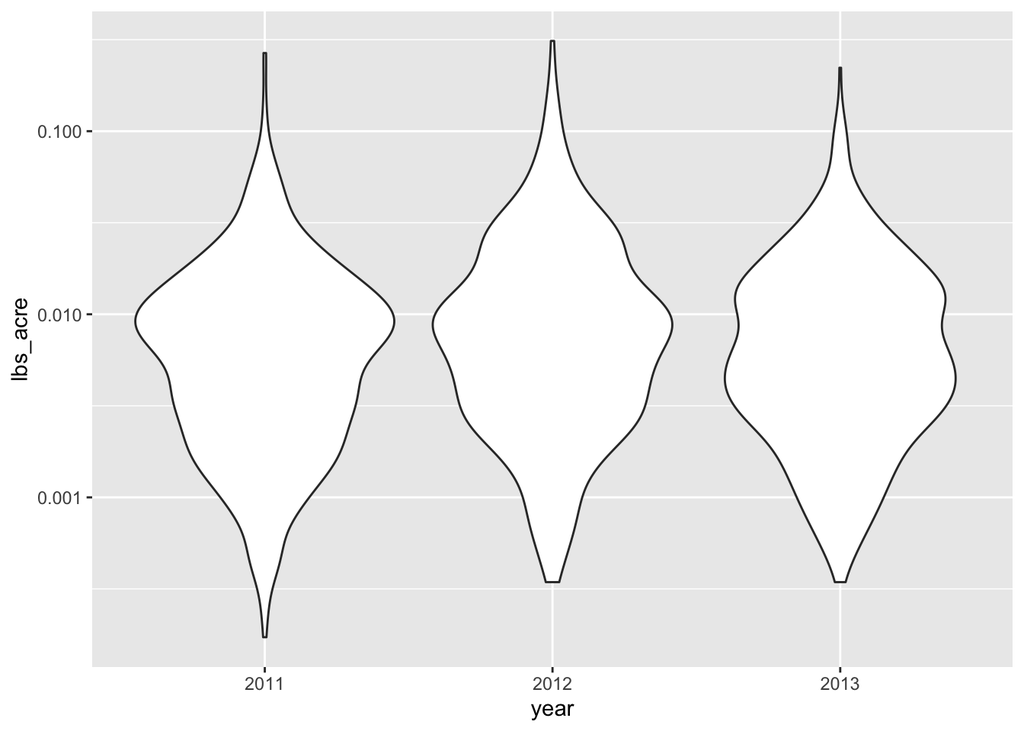

```r
ggplot(acre_all_year, aes(x = year, y = lbs_acre)) + geom_violin() +
  scale_y_log10()
```

We can also make one to show just the productive part of the garden.

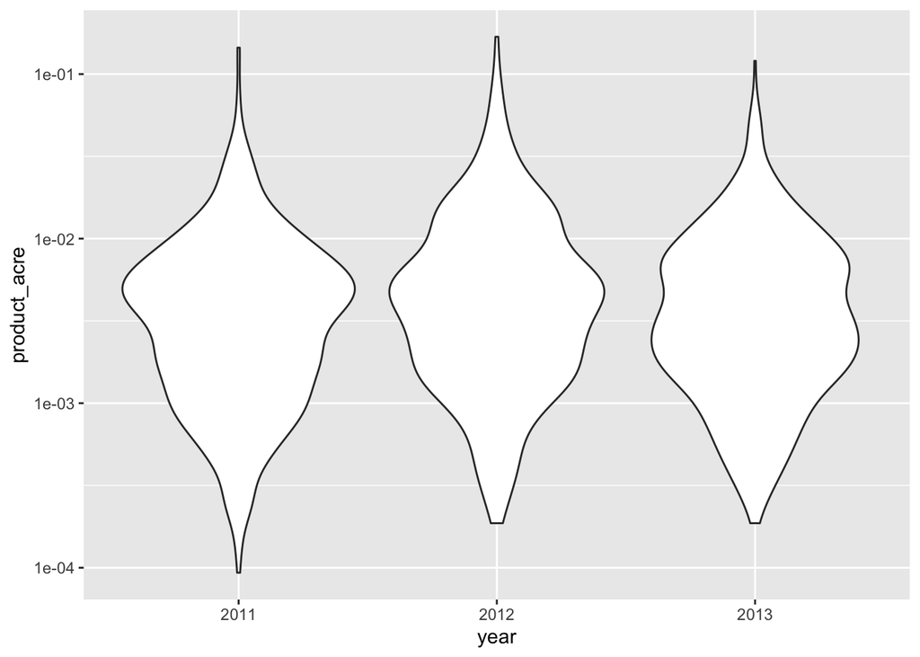

```r
ggplot(acre_all_year, aes(x = year, y = product_acre)) + geom_violin() +
  scale_y_log10()
```

With two violin plots showing our yearly productivity, we can also look at the productivity by family.

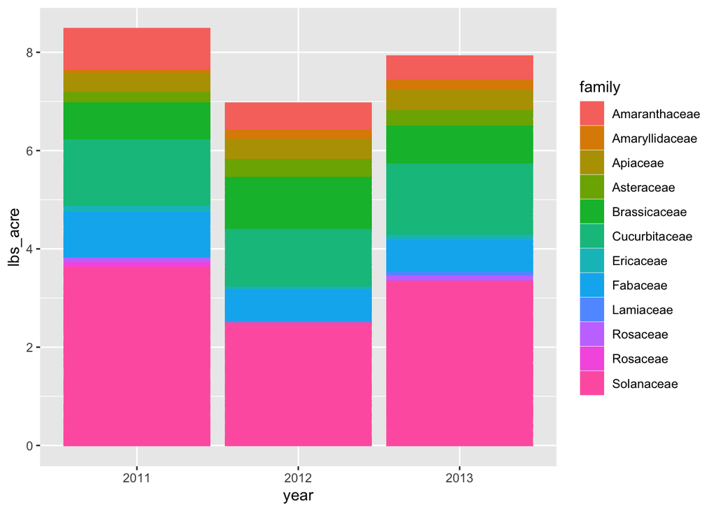

```r
ggplot(acre_all_year, aes(x = year, y = lbs_acre, fill = family,
                          color = family)) + geom_col()
```

We can see that by weight, family Solanaceae was the most productive! However, which crop of family Solanaceae was the more productive? By isolating the family, we can find out!

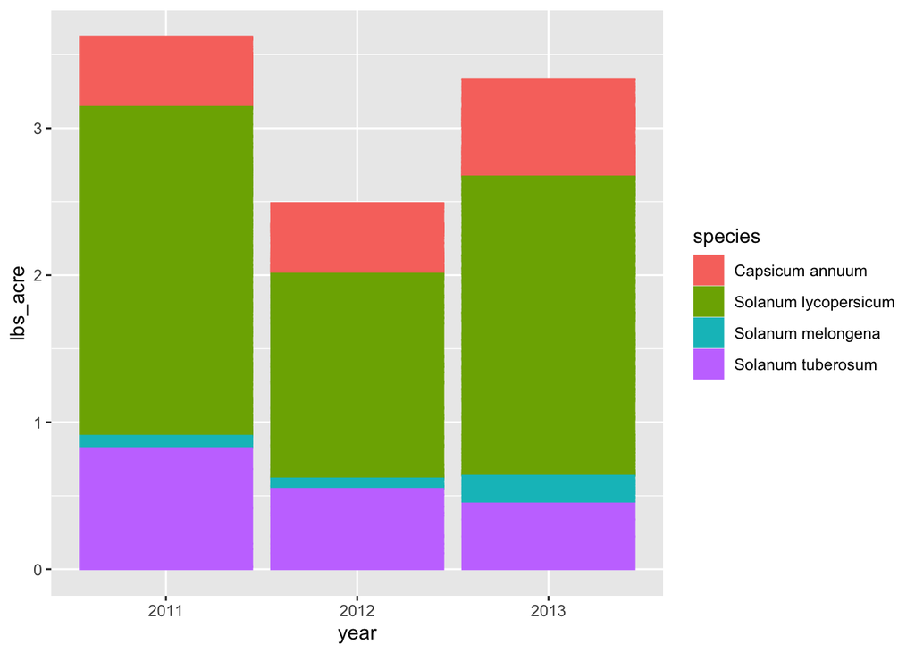

```r
solanaceae <- acre_all_year %>%
  filter(family == "Solanaceae")

ggplot(solanaceae, aes(x = year, y = lbs_acre, fill = species,
                       color = species)) + geom_col()
```

Based on this graph, species *Solanum lycopersicum* was the most productive species in the garden. This species contains tomatoes, of which the case study grew several varieties. Tomatoes were the most productive crop by weight probably because of their high water content, making them quite heavy. Based on this analysis,tomatoes were the most productive crop by lbs/acre.